# Digits classification

Digits classification

### 1. Project introduction

This project focuses on **classifying the digits** from **Digit images**. I’ll perform this classification by **KNN & SVM** method.

Since the interest of image recognition is getting higher in almost every industry in our society recently, I would like to perform the basic classification by using the Handwritten Digit Data in the `ElemStatLearn` package.

- **Tools:** R (caret / ElemStatLearn packages)
- **Data:** the Handwritten Digit Data in `ElemStatLearn` package (https://www.rdocumentation.org/packages/ElemStatLearn/versions/2015.6.26.2)
- **Analyses performed:** K-Nearest Neighbor (KNN), Linear/Radial Support Vector Machine (SVM)

### 2. Data description & exploration

#### Data description

- This dataset consist of two parts - train & test data. For both dataset, **the first column is the actual digit information**, and **the other columns are indicates each pixel’s values of the Digit image**.

#### Data exploration

- In this dataset, there are **7,291 observations with 257 variables** in the train data and **2,007 observations with 257 variables** in the test data. We can confirm this as below in order (train, test):

```
## [1] 7291  257
```

```
## [1] 2007  257
```

```
## [1] 1376  257
```

```
## [1] 345 257
```

### 3. Modeling

#### Fitting K-Nearest Neighbors (KNN)

```
## k-Nearest Neighbors
##
## 1376 samples
##  256 predictor
##    2 classes: '2', '7'
##
## No pre-processing
## Resampling: Cross-Validated (5 fold, repeated 3 times)
## Summary of sample sizes: 1101, 1101, 1100, 1101, 1101, 1100, ...
## Resampling results across tuning parameters:
##
##   k   Accuracy   Kappa
##    1  0.9866728  0.9732743
##    2  0.9840105  0.9679423
##    3  0.9849794  0.9698754
##    4  0.9842521  0.9684142
##    5  0.9844963  0.9689056
##    6  0.9825586  0.9650275
##    7  0.9830435  0.9659957
##    8  0.9811058  0.9621211
##    9  0.9818305  0.9635700
##   10  0.9818314  0.9635756
##
## Accuracy was used to select the optimal model using the largest value.
## The final value used for the model was k = 1.
```

- From the results, the best **K** seems $1$ and $3$, in terms of classification error (CV). Although the CV showed the lowest value when the $(K=1)$, it might cause overfitting issue.
- Thus, I will try to compare the prediction for $(k=1)$ and $(k=3)$ for deciding the best tuning **K**. We can see this by the graph (Classification error vs. K) as below:

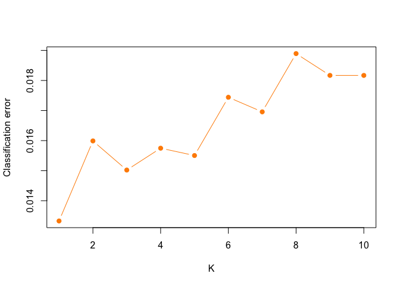

#### K-Nearest Neighbor (KNN) - Accuracy

- I checked the **Confusion Matrix** and the statistics including **Accuracy** of each model. We can see the results of the model with $(k=1)$ as below:

```
## Confusion Matrix and Statistics
##
##           Reference
## Prediction   2   7
##          2 193   1
##          7   5 146
##
##                Accuracy : 0.9826
##                  95% CI : (0.9625, 0.9936)
##     No Information Rate : 0.5739
##     P-Value [Acc > NIR] : <2e-16
##
##                   Kappa : 0.9646
##
##  Mcnemar's Test P-Value : 0.2207
##
##             Sensitivity : 0.9747
##             Specificity : 0.9932
##          Pos Pred Value : 0.9948
##          Neg Pred Value : 0.9669
##              Prevalence : 0.5739
##          Detection Rate : 0.5594
##    Detection Prevalence : 0.5623
##       Balanced Accuracy : 0.9840
##
##        'Positive' Class : 2
##
```

- The results of the model with $(k=3)$ is as below:

```
## Confusion Matrix and Statistics
##
##           Reference
## Prediction   2   7
##          2 194   1
##          7   4 146
##
##                Accuracy : 0.9855
##                  95% CI : (0.9665, 0.9953)
##     No Information Rate : 0.5739
##     P-Value [Acc > NIR] : <2e-16
##
##                   Kappa : 0.9704
##
##  Mcnemar's Test P-Value : 0.3711
##
##             Sensitivity : 0.9798
##             Specificity : 0.9932
##          Pos Pred Value : 0.9949
##          Neg Pred Value : 0.9733
##              Prevalence : 0.5739
##          Detection Rate : 0.5623
##    Detection Prevalence : 0.5652
##       Balanced Accuracy : 0.9865
##
##        'Positive' Class : 2
##
```

- From the results, the model with $(k=1)$ showed $98.26$% for accuracy and the model with $(k=3)$ showed $98.55$% for accuracy.
- Although the $(k=1)$ model has less cross-validation error than $(k=3)$ model, the $(k=3)$ model showed better testing error for prediction. Therefore, **I have chosen $(k=3)$ for best tuning parameter of my model**.

#### Fitting SVM - Linear

- To fit the Support Vectore Machine (SVM), we need to find the best *C* (cost) for linear SVM. I’ll use 10-fold cross-validation to find *C* from 0.001 to 0.2.

```
## Support Vector Machines with Linear Kernel
##
## 1376 samples
##  256 predictor
##    2 classes: '2', '7'
##
## No pre-processing
## Resampling: Cross-Validated (10 fold)
## Summary of sample sizes: 1238, 1238, 1237, 1239, 1239, 1239, ...
## Resampling results across tuning parameters:
##
##   cost        Accuracy   Kappa
##   0.00100000  0.9890987  0.9781289
##   0.01147368  0.9920025  0.9839578
##   0.02194737  0.9934624  0.9868800
##   0.03242105  0.9927325  0.9854173
##   0.04289474  0.9912832  0.9825163
##   0.05336842  0.9927378  0.9854392
##   0.06384211  0.9927378  0.9854392
##   0.07431579  0.9927378  0.9854392
##   0.08478947  0.9927378  0.9854392
##   0.09526316  0.9934677  0.9869068
##   0.10573684  0.9934677  0.9869068
##   0.11621053  0.9927378  0.9854421
##   0.12668421  0.9927378  0.9854421
##   0.13715789  0.9927378  0.9854421
##   0.14763158  0.9927378  0.9854421
##   0.15810526  0.9927378  0.9854421
##   0.16857895  0.9927378  0.9854421
##   0.17905263  0.9927378  0.9854421
##   0.18952632  0.9927378  0.9854421
##   0.20000000  0.9927378  0.9854421
##
## Accuracy was used to select the optimal model using the largest value.
## The final value used for the model was cost = 0.09526316.
```

- The best *C* is $0.0952$ based on the accuracy.

#### Linear SVM - Accuracy

- I have obtained the confusion table with the best *C* ($0.0952$) as below, and we can see the accuracy of this SVM model is $98.84$%, which is pretty reliable.

```
##
## svm_lin_pred   2   7
##            2 196   2
##            7   2 145
```

```
## [1] 0.9884058
```

#### Fitting SVM - Radial

- To fit the **Radial** SVM, we need to decide the best *C* and `sigma` first. I’ll perform 10-fold cross-validation and repeat it 3 times.

```
## Support Vector Machines with Radial Basis Function Kernel
##
## 1376 samples
##  256 predictor
##    2 classes: '2', '7'
##
## No pre-processing
## Resampling: Cross-Validated (10 fold, repeated 3 times)
## Summary of sample sizes: 1238, 1238, 1237, 1239, 1239, 1239, ...
## Resampling results across tuning parameters:
##
##   C     sigma  Accuracy   Kappa
##   0.25  0.005  0.9903082  0.9805245
##   0.25  0.010  0.9907913  0.9814923
##   0.25  0.015  0.9903099  0.9805074
##   0.50  0.005  0.9907930  0.9815026
##   0.50  0.010  0.9915177  0.9829483
##   0.50  0.015  0.9910398  0.9819760
##   0.75  0.005  0.9912761  0.9824696
##   0.75  0.010  0.9910346  0.9819788
##   0.75  0.015  0.9907965  0.9814948
##
## Accuracy was used to select the optimal model using the largest value.
## The final values used for the model were sigma = 0.01 and C = 0.5.
```

- I have obtained the best *C* $(0.5)$ and `sigma` $(0.01)$ based on the accuracy.

#### Radial SVM - Accuracy

- I have obtained the confusion table above, and the testing data accuracy was $98.55$% based on those *C* and the `sigma`.

```
##             test.y
## svm_rad_pred   2   7
##            2 197   4
##            7   1 143
```

```
## [1] 0.9855072
```

#### A comparison between **KNN** / **Linear SVM** / **Radial SVM** methods

- The comparison between three classification methods are as below:

[output not shown]

- From the results, we can conclude that **Linear SVM** model showed better in terms of accuracy. However, the results could be changed when we use another dataset or different conditions.

#### 4. Conclusion

- From the analyzing results, our **Linear Support Vectore Machine (SVM)** showed the best accuracy $98.84$%. However, the other models **(KNN, Radial SVM)** also showed pretty reliable accuracy.
- Since we performed those classification method only with two digits $2$ and $7$ from the dataset, this model would be improved its classification ability if we put more observations than just 2 digits.